# Credit Card Fraud Detection Using Random Forest

Wei-Lin Zheng

The data is downloaded from kaggle: credit card fraud detection.

Here I use randomforest to fit the data, and use nested cross validation (Nested CV) to find the best tuning parameter: mtry.

# Step 1. Load and Observe the data

```r
data <- read.csv("D:\\creditcard.csv")
names(data)
```

```
##  [1] "Time"   "V1"     "V2"     "V3"     "V4"     "V5"     "V6"
##  [8] "V7"     "V8"     "V9"     "V10"    "V11"    "V12"    "V13"
## [15] "V14"    "V15"    "V16"    "V17"    "V18"    "V19"    "V20"
## [22] "V21"    "V22"    "V23"    "V24"    "V25"    "V26"    "V27"
## [29] "V28"    "Amount" "Class"
```

From V1 to V28 are principal components of features, which we don’t know because of privacy issue. The column “Class” refers to fraud. 1 means fraud and 0 means not fraud.

```r
summary(data)
```

```
##       Time              V1                  V2
##  Min.   :     0   Min.   :-56.40751   Min.   :-72.71573
##  1st Qu.: 54202   1st Qu.: -0.92037   1st Qu.: -0.59855
##  Median : 84692   Median :  0.01811   Median :  0.06549
##  Mean   : 94814   Mean   :  0.00000   Mean   :  0.00000
##  3rd Qu.:139321   3rd Qu.:  1.31564   3rd Qu.:  0.80372
##  Max.   :172792   Max.   :  2.45493   Max.   : 22.05773
##        V3                 V4                 V5
##  Min.   :-48.3256   Min.   :-5.68317   Min.   :-113.74331
##  1st Qu.: -0.8904   1st Qu.:-0.84864   1st Qu.:  -0.69160
##  Median :  0.1799   Median :-0.01985   Median :  -0.05434
##  Mean   :  0.0000   Mean   : 0.00000   Mean   :   0.00000
##  3rd Qu.:  1.0272   3rd Qu.: 0.74334   3rd Qu.:   0.61193
##  Max.   :  9.3826   Max.   :16.87534   Max.   :  34.80167
##        V6                 V7                 V8
##  Min.   :-26.1605   Min.   :-43.5572   Min.   :-73.21672
##  1st Qu.: -0.7683   1st Qu.: -0.5541   1st Qu.: -0.20863
##  Median : -0.2742   Median :  0.0401   Median :  0.02236
##  Mean   :  0.0000   Mean   :  0.0000   Mean   :  0.00000
##  3rd Qu.:  0.3986   3rd Qu.:  0.5704   3rd Qu.:  0.32735
##  Max.   : 73.3016   Max.   :120.5895   Max.   : 20.00721
##        V9                 V10                 V11
##  Min.   :-13.43407   Min.   :-24.58826   Min.   :-4.79747
##  1st Qu.: -0.64310   1st Qu.: -0.53543   1st Qu.:-0.76249
##  Median : -0.05143   Median : -0.09292   Median :-0.03276
##  Mean   :  0.00000   Mean   :  0.00000   Mean   : 0.00000
##  3rd Qu.:  0.59714   3rd Qu.:  0.45392   3rd Qu.: 0.73959
##  Max.   : 15.59500   Max.   : 23.74514   Max.   :12.01891
##       V12                V13                V14
##  Min.   :-18.6837   Min.   :-5.79188   Min.   :-19.2143
##  1st Qu.: -0.4056   1st Qu.:-0.64854   1st Qu.: -0.4256
##  Median :  0.1400   Median :-0.01357   Median :  0.0506
##  Mean   :  0.0000   Mean   : 0.00000   Mean   :  0.0000
##  3rd Qu.:  0.6182   3rd Qu.: 0.66251   3rd Qu.:  0.4931
##  Max.   :  7.8484   Max.   : 7.12688   Max.   : 10.5268
##       V15                V16                 V17
##  Min.   :-4.49894   Min.   :-14.12985   Min.   :-25.16280
##  1st Qu.:-0.58288   1st Qu.: -0.46804   1st Qu.: -0.48375
##  Median : 0.04807   Median :  0.06641   Median : -0.06568
##  Mean   : 0.00000   Mean   :  0.00000   Mean   :  0.00000
```

[output cut: 22 more lines]

```
##  Max.   : 4.58455   Max.   :  7.51959   Max.   : 3.51735
##       V27                  V28                Amount
##  Min.   :-22.565679   Min.   :-15.43008   Min.   :    0.00
##  1st Qu.: -0.070840   1st Qu.: -0.05296   1st Qu.:    5.60
##  Median :  0.001342   Median :  0.01124   Median :   22.00
##  Mean   :  0.000000   Mean   :  0.00000   Mean   :   88.35
##  3rd Qu.:  0.091045   3rd Qu.:  0.07828   3rd Qu.:   77.17
##  Max.   : 31.612198   Max.   : 33.84781   Max.   :25691.16
##      Class
##  Min.   :0.000000
##  1st Qu.:0.000000
##  Median :0.000000
##  Mean   :0.001728
##  3rd Qu.:0.000000
##  Max.   :1.000000
```

```r
table(data$Class)
```

```
##
##      0      1
## 284315    492
```

The class is unbalanced, which I need some techniques to handle. I handle it using stratified sampling, but there are other ways to deal with it like oversampling, undersampling, or weighted cost. Here I use SMOTE to deal with this problem.

# Step 2. Prepare for Analyzing

Note that when doing nested cross validation, I decide to do the following procedures:

1. I choose one parameter: mtry (number of splits).
2. I use averaged F1 score to do evaluation, due to this article: https://stats.stackexchange.com/a/252451. I use F1 score not only because it is intuitive, but also because sometimes AUC may be poor to evaluate models on unbalanced data, as this article says.

```r
library(caret, quietly=TRUE)   #for stratified sampling, computing prec,recall
library(DMwR, quietly=TRUE) #for SMOTE
set.seed(101)
fold <- createFolds(factor(data$Class), k=5, list=FALSE) #Construct five stratified folds
table(data$Class[fold==1])
```

```
##
##     0     1
## 56863    98
```

Take fold=1 as an example, the percent of 1 in the fold is equal to one in the whole data set.

```r
x <- model.matrix(Class~.-Time-1, data=data)
# Since "Time" is not meaningful to the analysis, I omit it.
data$Class <- as.factor(data$Class)
y <- data$Class
bestmtry <- rep(0,5)
outerlist <- list()
oconfusionM <- list()
oevaluation <- list()
```

# Step 3. Analyzing: Randomforest and Nested CV

```r
library(randomForest, quietly=TRUE)

for (i in 1:5) {
    F1 <- rep(0,4)
    for (j in 1:4) {
        #inner cv for mtry
        k <- ifelse(i+j>5, (i+j)%%5, i+j)
        cond <- fold==i | fold==k
        Smote <- SMOTE(Class~.-Time, data=data[cond,], perc.over=300, perc.under=1000)
        xs <- model.matrix(Class~.-Time-1, data=Smote)
        ys <- Smote$Class
        for (m in 2:5) {
            inner <- randomForest(xs, ys, mtry=m)
            inpred <- predict(inner, x[fold==k,])
            determ1 <- factor(inpred, c(1,0))
            determ2 <- factor(y[fold==k], c(1,0))
            inpred.table <- table(determ1, determ2)
            cmatrix <- confusionMatrix(inpred.table, mode="prec_recall")
            F1[m-1] <- F1[m-1] + cmatrix$byClass["F1"]
            }
        }
    maxima <- which(F1==max(F1), arr.ind=TRUE)
    bestmtry[i] <- maxima+1

    oSmote <- SMOTE(Class~.-Time, data=data[fold!=i,], perc.over=300, perc.under=1000)
    xo <- model.matrix(Class~.-Time-1, data=oSmote)
    yo <- oSmote$Class
    outer <- randomForest(xo, yo, mtry=bestmtry[i], importance=TRUE)
    outerlist <- append(outerlist, list(outer))
    pred <- predict(outer, x[fold==i,])
    odeterm1 <- factor(pred, c(1,0))
    odeterm2 <- factor(y[fold==i], c(1,0))
    pred.table <- table(odeterm1, odeterm2)
    outercmatrix <- confusionMatrix(pred.table, mode="prec_recall")
    oconfusionM <- append(oconfusionM, list(outercmatrix$table))
    oevaluation <- append(oevaluation, list(outercmatrix$byClass["F1"]))
    }
```

# Step 4. Check the Consistency of Outer Fold to Determine the Model is Stable or not.

This is great to use nested CV because we can examine the stability of the model. If the model is unstable, it means that when we use different data to fit the same model, the result is not countable, which is problematic.

Here I examine 4 important labels to check the consistency.

### 4.1 mtry (number of splits)

```r
bestmtry
```

```
## [1] 2 2 2 2 2
```

### 4.2 Importance of Features

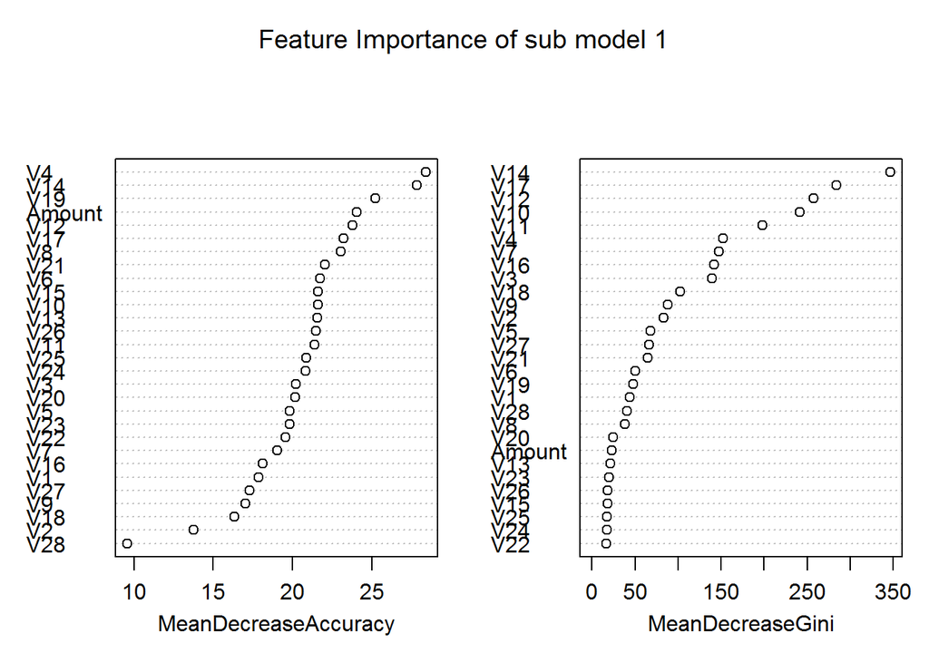

```r
varImpPlot(outerlist[[1]], main="Feature Importance of sub model 1")
```

The following graphs is constructed by above similar codes, but describes the other 4 sub models.

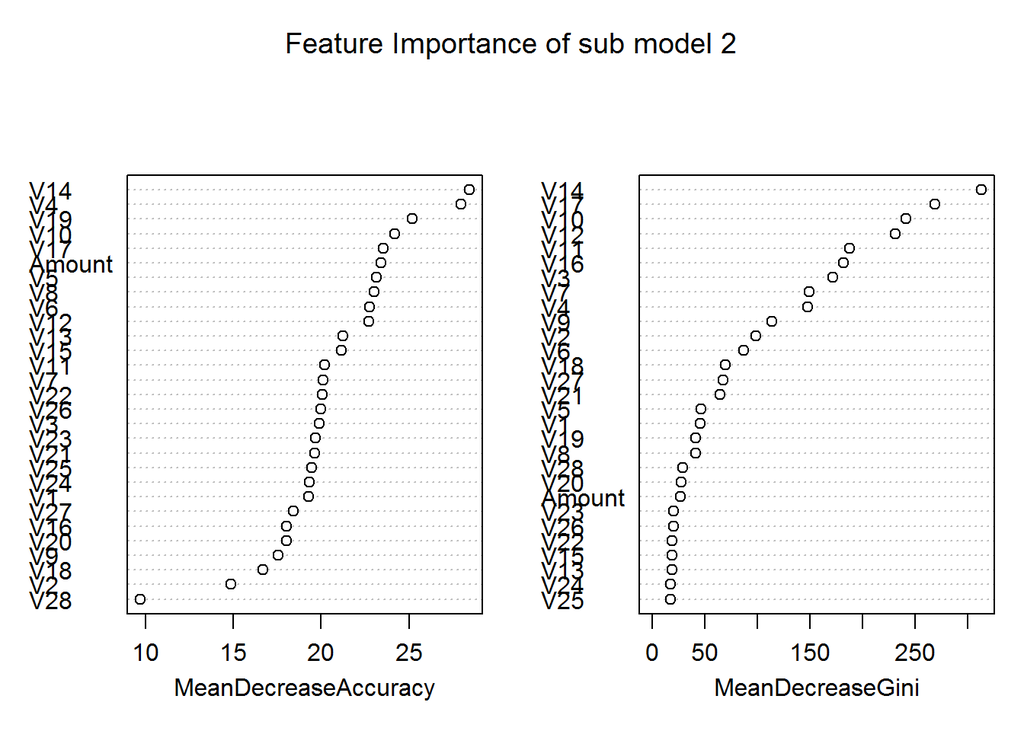

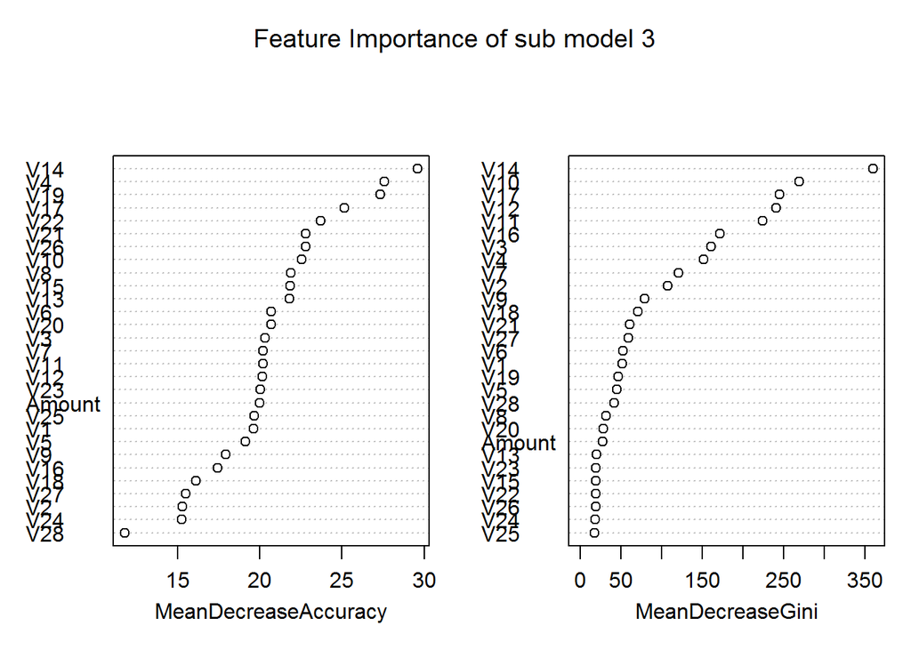

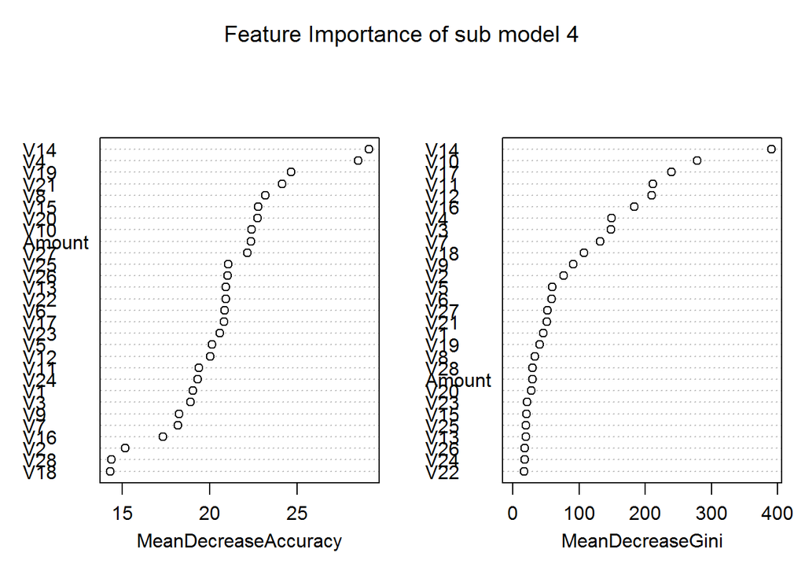

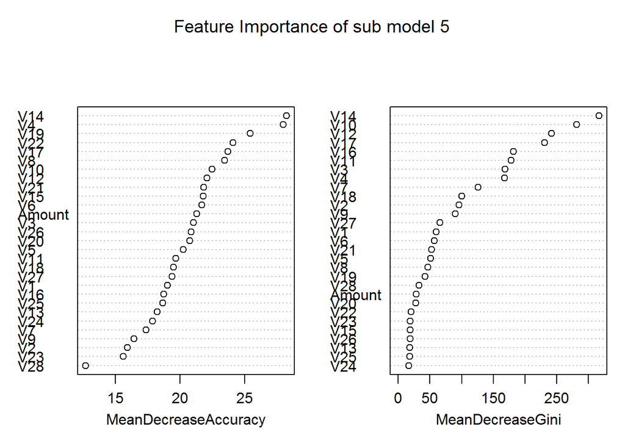

### 4.3 Confusion Matrix

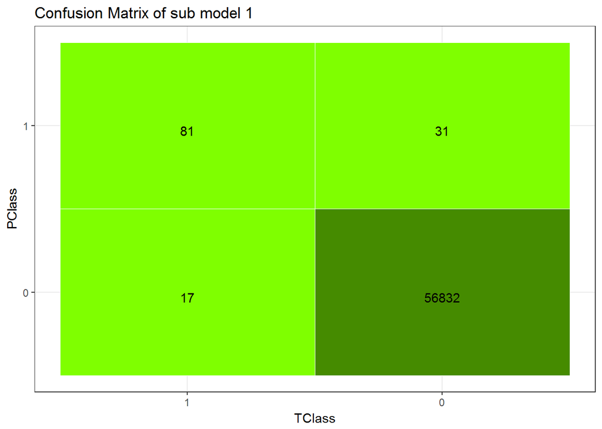

```r
TClass <- factor(c(0,0,1,1))
PClass <- factor(c(1,0,1,0))

Y <- as.numeric(oconfusionM[[1]])
df <- data.frame(TClass, PClass, Y)
ggplot(data=df, mapping = aes(x=TClass, y=PClass)) +
  geom_tile(aes(fill=Y), colour="white") +
  geom_text(aes(label=sprintf("%1.0f", Y)), vjust=1) +
  scale_fill_gradient(low="chartreuse", high="chartreuse4") +
  theme_bw() + theme(legend.position="none") +
  scale_x_discrete(labels=c(1,0)) +
  ggtitle("Confusion Matrix of sub model 1")
```

The following graphs is constructed by above similar codes, but describes the other 4 sub models.

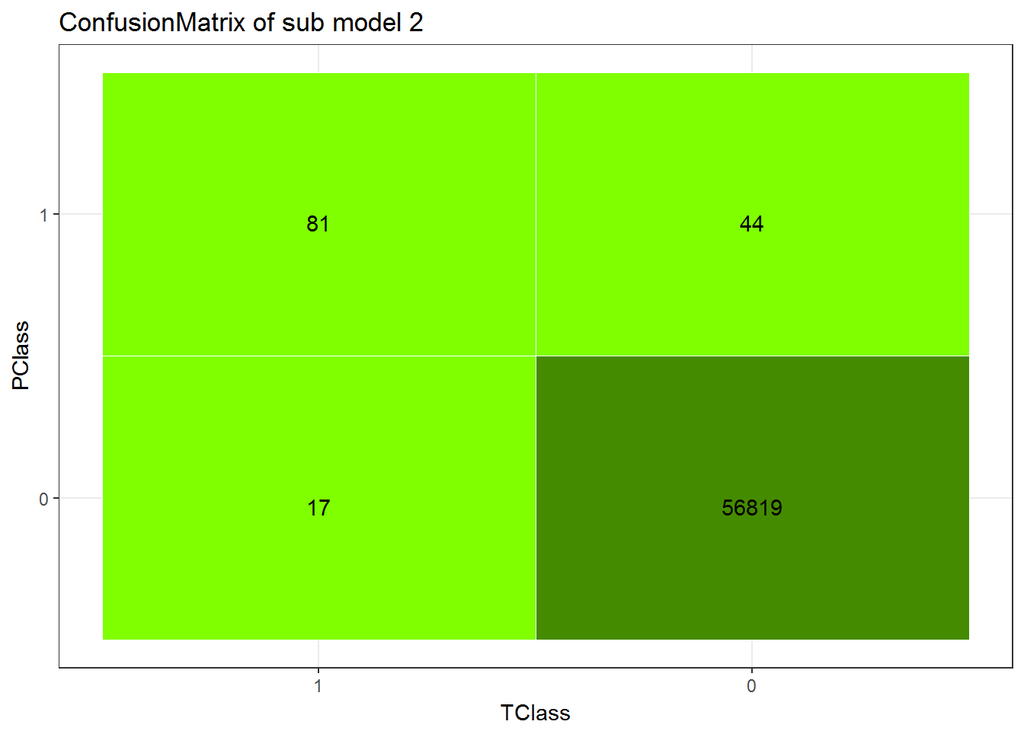

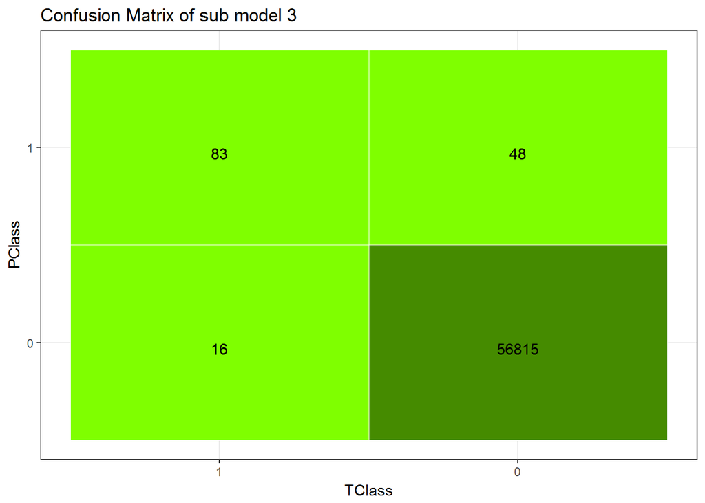

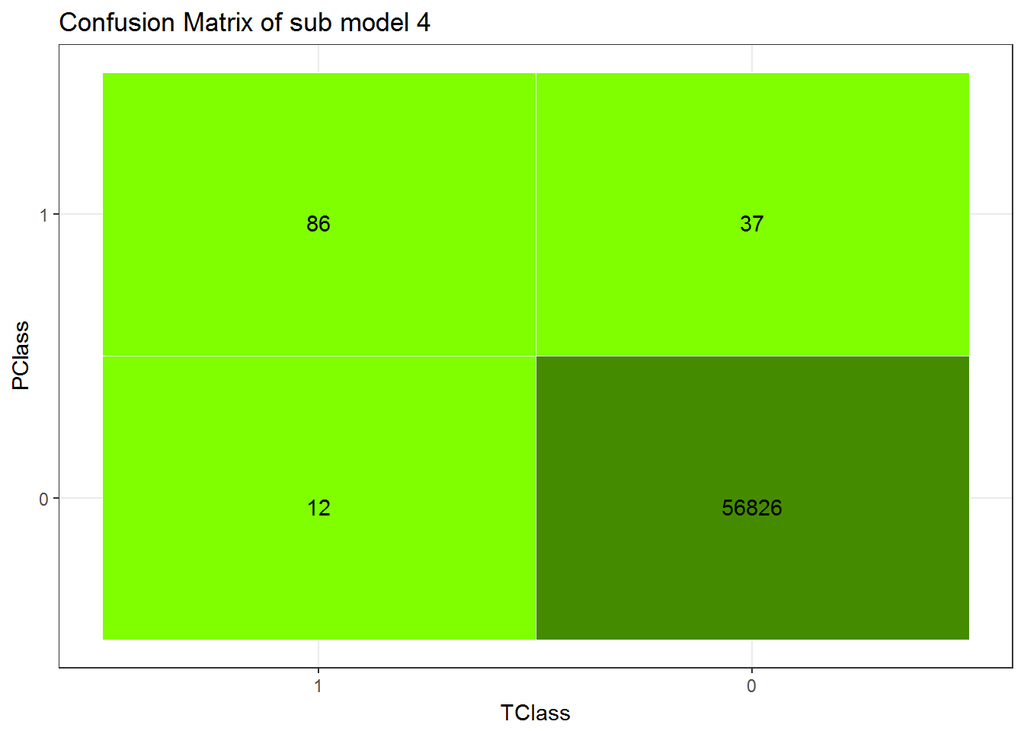

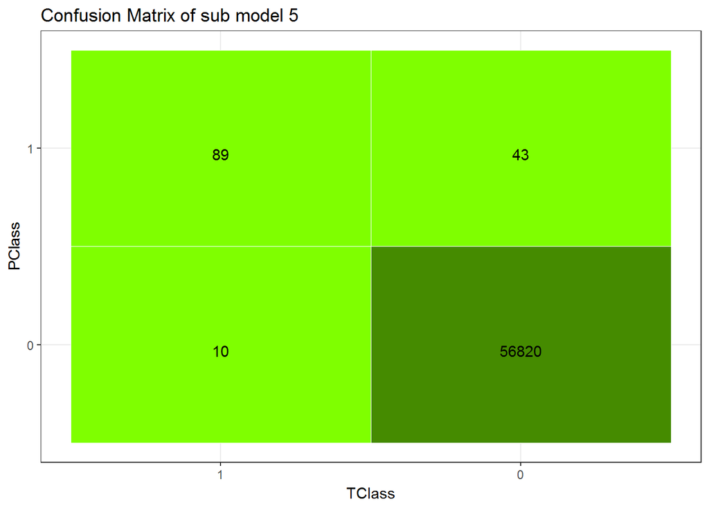

### 4.4 Evaluation: F1 Score

```r
oevaluation
```

```
## [[1]]
##        F1
## 0.7714286
##
## [[2]]
##        F1
## 0.7264574
##
## [[3]]
##        F1
## 0.7217391
##
## [[4]]
##        F1
## 0.7782805
##
## [[5]]
##        F1
## 0.7705628
```